# First Predictive Text Model

Back-off n-grams, validation, efficiency and accuracy

Sonja Sahebzad

2026-09-19

# Purpose

This report builds and evaluates a first next-word prediction model from the official English SwiftKey corpus [1]. The main question is practical: how much predictive performance can be retained while reducing memory use and response time? The model uses the established n-gram and back-off principle described in the language-modeling literature [2, 3].

# Data and validation design

The three source files are sampled reproducibly. Lines are split into training and validation partitions before any n-grams are counted. The final word of each selected validation line is hidden and used as the target; all preceding words form the input phrase. This prevents evaluation on phrases used to build the model.

```r
paths <- c(
  blogs = file.path("data", "final", "en_US", "en_US.blogs.txt"),
  news = file.path("data", "final", "en_US", "en_US.news.txt"),
  twitter = file.path("data", "final", "en_US", "en_US.twitter.txt")
)
stopifnot(all(file.exists(paths)))
```

```r
dir.create("models", showWarnings = FALSE)
artifact_path <- file.path("models", "first_backoff_model.rds")

if (file.exists(artifact_path)) {
  artifacts <- readRDS(artifact_path)
} else {
  sampled <- sample_corpus_lines(
    paths,
    probability = 0.02,
    maximum_per_source = 60000L
  )
  split <- split_training_validation(sampled)
  raw_model <- build_ngram_model(split$training$text, maximum_order = 4L)
  validation_cases <- make_validation_cases(split$validation$text, maximum_cases = 1000L)
  artifacts <- list(
    sample_summary = as.data.frame(table(sampled$source)),
    raw_model = raw_model,
    validation_cases = validation_cases
  )
  saveRDS(artifacts, artifact_path, compress = "xz")
}

knitr::kable(
  artifacts$sample_summary,
  col.names = c("Source", "Sampled lines"),
  caption = "Reproducible corpus sample used for model development"
)
```

Reproducible corpus sample used for model development

| Source | Sampled lines |
| --- | --- |
| blogs | 17883 |
| news | 20324 |
| twitter | 46989 |

# Model

The model counts unigrams, bigrams, trigrams and four-grams. For a new phrase it first searches the longest available context. If that context is absent, it backs off to a shorter context and finally to overall word frequency. This gives specific predictions when evidence is available while retaining coverage for unfamiliar phrases.

Three pruning settings are compared. A threshold of one retains every observed sequence. Higher thresholds discard rare multiword sequences, which can reduce model size and sometimes improve generalization by removing noise.

```r
candidate_models <- lapply(c(1L, 2L, 3L), function(threshold) {
  prune_ngram_model(artifacts$raw_model, minimum_count = threshold)
})

evaluation <- rbindlist(lapply(
  candidate_models,
  evaluate_ngram_model,
  cases = artifacts$validation_cases
))
write.csv(
  evaluation,
  file.path("models", "candidate_evaluation.csv"),
  row.names = FALSE
)

display <- copy(evaluation)
display[, `:=`(
  top1_accuracy = scales::percent(top1_accuracy, accuracy = 0.1),
  top2_accuracy = scales::percent(top2_accuracy, accuracy = 0.1),
  top3_accuracy = scales::percent(top3_accuracy, accuracy = 0.1),
  mean_reciprocal_rank = round(mean_reciprocal_rank, 3),
  perplexity = round(perplexity, 1),
  milliseconds_per_prediction = round(milliseconds_per_prediction, 2),
  model_size_mib = round(model_size_mib, 1)
)]
knitr::kable(display, caption = "Held-out accuracy and efficiency by pruning threshold")
```

Held-out accuracy and efficiency by pruning threshold

| minimum_count | validation_cases | top1_accuracy | top2_accuracy | top3_accuracy | mean_reciprocal_rank | perplexity | milliseconds_per_prediction | model_size_mib |
| --- | --- | --- | --- | --- | --- | --- | --- | --- |
| 1 | 1000 | 8.8% | 12.6% | 14.3% | 0.113 | 28800.2 | 5.63 | 166.1 |
| 2 | 1000 | 8.9% | 11.7% | 13.9% | 0.110 | 20631.3 | 7.42 | 13.9 |
| 3 | 1000 | 7.8% | 10.5% | 12.4% | 0.098 | 19334.3 | 8.73 | 8.8 |

# Accuracy and efficiency trade-off

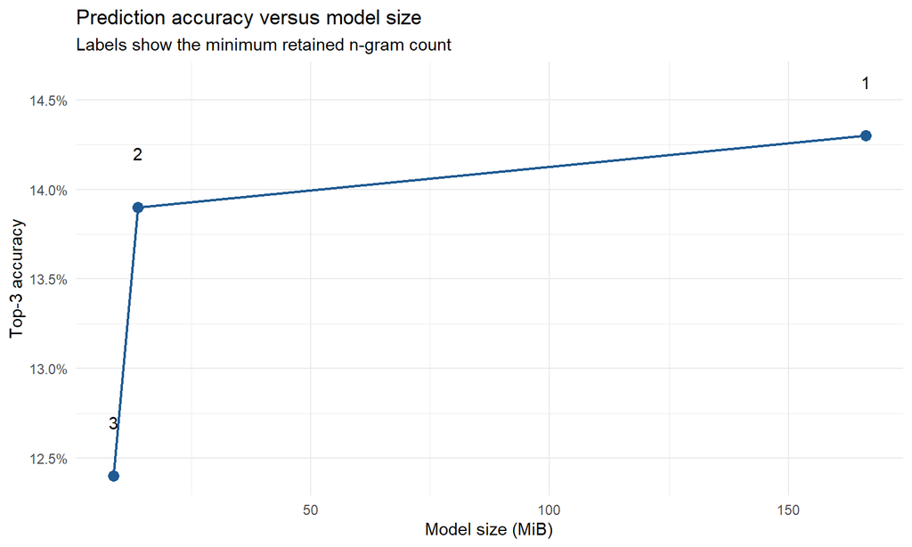

```r
ggplot(evaluation, aes(model_size_mib, top3_accuracy, label = minimum_count)) +
  geom_line(color = "#1f5a92", linewidth = 0.8) +
  geom_point(color = "#1f5a92", size = 3) +
  geom_text(nudge_y = 0.003, color = "black") +
  scale_y_continuous(labels = scales::percent_format(accuracy = 0.1)) +
  labs(
    title = "Prediction accuracy versus model size",
    subtitle = "Labels show the minimum retained n-gram count",
    x = "Model size (MiB)",
    y = "Top-3 accuracy"
  ) +
  theme_minimal(base_family = "Segoe UI")
```

Top-1 accuracy requires the correct word to rank first. Top-2 and top-3 accuracy give credit when it appears among the first two or three suggestions. Mean reciprocal rank rewards correct words more strongly when they appear near the top. Perplexity measures how surprised the probability model is by unseen validation text; lower values are better. Response time and memory size capture whether the model is practical for an interactive app.

```r
best_index <- which.max(
  evaluation$top3_accuracy -
    0.0001 * evaluation$model_size_mib -
    0.0001 * evaluation$milliseconds_per_prediction
)
selected_model <- candidate_models[[best_index]]
selected_result <- evaluation[best_index, ]

saveRDS(selected_model, file.path("models", "selected_backoff_model.rds"), compress = "xz")
knitr::kable(selected_result, caption = "Selected candidate for the first interactive prototype")
```

Selected candidate for the first interactive prototype

| minimum_count | validation_cases | top1_accuracy | top2_accuracy | top3_accuracy | mean_reciprocal_rank | perplexity | milliseconds_per_prediction | model_size_mib |
| --- | --- | --- | --- | --- | --- | --- | --- | --- |
| 2 | 1000 | 0.089 | 0.117 | 0.139 | 0.1103333 | 20631.28 | 7.42 | 13.86478 |

## What the values mean

The selected threshold is **2**, so a multiword sequence must occur at least twice to remain in the model. This reduces the in-memory model from **166.1 MiB** to **13.9 MiB**, a **91.7% reduction**. Top-1 accuracy is **8.9%**, meaning the first suggestion is correct about nine times per 100 validation phrases. Top-3 accuracy is **13.9%**, only **0.4 percentage points lower** than the unpruned model. Each prediction takes approximately **7.42 milliseconds**, which is fast enough for an interactive prototype.

Perplexity falls by **28.4%** relative to the unpruned candidate. Lower perplexity means the model assigns less surprise to held-out text. Its absolute value remains high because the vocabulary is large and the training sample is deliberately limited. Perplexity and ranking accuracy therefore do not move in exactly the same direction. Raising the threshold to three reduces memory further but lowers top-3 accuracy by **1.5 percentage points**, so that option prunes too aggressively for the small additional saving.

# Independent prediction examples

These neutral examples demonstrate the interface. They are not part of the validation set and are not assessment questions.

```r
examples <- c("I went to the", "Thank you for the", "This is a very")
example_predictions <- rbindlist(lapply(examples, function(text) {
  result <- predict_next(selected_model, text, top_n = 3L)
  result[, input := text]
  result
}), fill = TRUE)

knitr::kable(
  example_predictions[, .(input, rank, word, context_order)],
  caption = "Three next-word suggestions for neutral example phrases"
)
```

Three next-word suggestions for neutral example phrases

| input | rank | word | context_order |
| --- | --- | --- | --- |
| I went to the | 1 | book | 4 |
| I went to the | 2 | city | 4 |
| I went to the | 3 | er | 4 |
| Thank you for the | 1 | rt | 4 |
| Thank you for the | 2 | follow | 4 |
| Thank you for the | 3 | mention | 4 |
| This is a very | 1 | good | 4 |
| This is a very | 2 | important | 4 |
| This is a very | 3 | interesting | 4 |

# Discussion

The candidate comparison answers the central trade-off question directly. The threshold-two model retains nearly all ranking accuracy while using much less memory, making it the strongest candidate for Shiny. The threshold-three model is smaller but loses more top-3 accuracy. Perplexity is reported alongside ranking accuracy because a probability model can improve its average confidence without improving which word is placed first. The two measures therefore need not move together.

The current evaluation is an honest first benchmark, not a final performance claim. Accuracy depends on sample size, source mix, normalization and the amount of rare context retained. Before deployment, the chosen model should also be tested separately on blogs, news and Twitter and checked for profanity, undesirable suggestions and latency on the hosting environment.

# Reproducibility

The workflow can be rerun from the R Markdown source. It uses the official corpus files, documented parameters and fixed random seeds. Training and validation are separated before n-gram construction. Generated model objects are excluded from Git because they can be rebuilt; the compact benchmark table is retained in `models/candidate_evaluation.csv`.

Parameters needed to reproduce the benchmark

| Item | Value |
| --- | --- |
| Corpus sample | 2% per source, maximum 60,000 lines per source |
| Validation split | 15% of sampled lines, separated before training |
| Validation cases | 1,000 held-out final-word predictions |
| Random seeds | 20260919, 20260920 and 20260921 |
| Maximum n-gram order | 4 |
| Core packages | R 4.6.1; data.table 1.18.6.1; stringi 1.8.9 |

# Conclusion

This reproducible workflow produces a working back-off predictor and measures predictive quality, speed and memory use on held-out text. The selected model is saved for the interactive prototype. The next development step is to validate the chosen configuration on a larger sample, add profanity filtering and connect the predictor to a mobile-friendly Shiny interface.

# How to try the model

After knitting this report, run `source("13_try_predictor.R")` in the RStudio Console. Enter any short English phrase. For exploration, the script first searches the official corpus for a directly observed continuation using progressively shorter contexts. If none is found, it uses the selected compact back-off model. The script prints the three highest-ranked suggestions, supporting corpus counts when available and the context order used. The held-out benchmark above evaluates only the compact model, so the two stages remain clearly distinguished.

# References

1. Coursera and SwiftKey. *Data Science Capstone training corpus*. [Official dataset download](https://d396qusza40orc.cloudfront.net/dsscapstone/dataset/Coursera-SwiftKey.zip).
2. Katz, S. M. (1987). Estimation of probabilities from sparse data for the language model component of a speech recognizer. *IEEE Transactions on Acoustics, Speech, and Signal Processing, 35*(3), 400-401. https://doi.org/10.1109/TASSP.1987.1165125.
3. Jurafsky, D., and Martin, J. H. *Speech and Language Processing*, Language Models with N-Grams. [Stanford draft](https://web.stanford.edu/~jurafsky/slp3/).
4. Dowle, M., and Srinivasan, A. *data.table: Extension of data.frame*. [CRAN package page](https://cran.r-project.org/package=data.table).
5. Gagolewski, M. *stringi: Fast and Portable Character String Processing Facilities*. [CRAN package page](https://cran.r-project.org/package=stringi).